# Exam 1

SOLUTIONS

2018-06-24 16:35:07

**NOTE: All plots should have appropriate titles and axis labels. If you need to use a calculated numerical answer in a subsequent analysis, you should store it and call it back when needed, not type the value by hand. If you store a calculated answer, be sure to print it as well so I can see it.**

### PROBLEM 1

In January 2007, Entertainment Weekly magazine featured a cover story about three Academy Award nominees for Best Actress: Meryl Streep, Judy Densch, and Helen Mirren. A major focus of the article was how old these three women were and the perceived Hollywood bias in favor of younger actresses, a discussion that persists in one form or another to this day. (data: oscarages.csv)

1. Create a dataset that contains only winners prior to 2007.

```r
OSCAR2007 <- OSCAR %>% filter(ceremony < 2007)
```

2. Compute five-number summaries to compare the ages of Best Actor and Best Actress winners prior to 2007.

```r
OSCAR2007 %>%
  filter(category %in% c("Best Actor", "Best Actress")) %>%
  group_by(category) %>%
  summarize(Min = fivenum(age)[1],
            Q1  = fivenum(age)[2],
            Med = fivenum(age)[3],
            Q3  = fivenum(age)[4],
            Max = fivenum(age)[5])
```

```
## # A tibble: 2 x 6
##   category       Min    Q1   Med    Q3   Max
##   <fct>        <dbl> <dbl> <dbl> <dbl> <dbl>
## 1 Best Actor      29  37.5    42  48.5    74
## 2 Best Actress    21  27.5    33  38.5    81
```

3. Create boxplots to compare the ages of Best Actor and Best Actress winners prior to 2007.

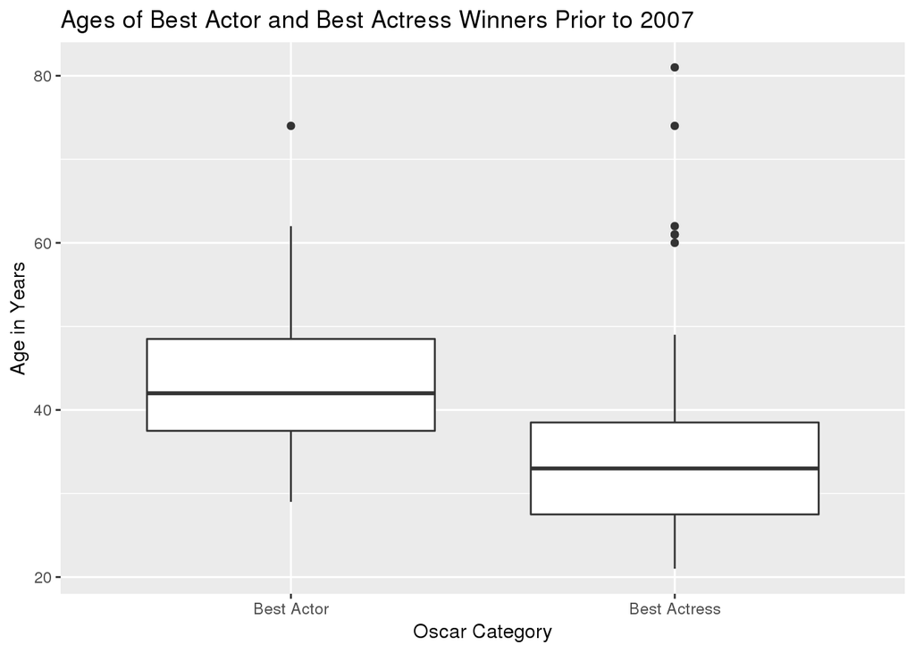

```r
ggplot(filter(OSCAR2007, category %in% c("Best Actor", "Best Actress")), aes(x = category, y = age)) +
  geom_boxplot() +
  ggtitle("Ages of Best Actor and Best Actress Winners Prior to 2007") +
  xlab("Oscar Category") +
  ylab("Age in Years")
```

4. What are the upper and lower fences for the two groups?

```r
fences <- OSCAR2007 %>%
  filter(category %in% c("Best Actor", "Best Actress")) %>%
  group_by(category) %>%
  summarize(lower = fivenum(age)[2] - 1.5 * IQR(age),
            upper = fivenum(age)[4] + 1.5 * IQR(age))
print.data.frame(fences)
```

```
##       category lower upper
## 1   Best Actor    21    65
## 2 Best Actress    11    55
```

5. Which actress actually won the Best Actress Oscar in 2007? How old was she? For what movie did she win? Use the `filter` and `select` functions in `dplyr` to get the answer, not visual inspection of the data.

```r
winner <- OSCAR %>%
  filter(ceremony == "2007" & category == "Best Actress") %>%
  select(name, age, title)
print.data.frame(winner)
```

```
##           name age     title
## 1 Helen Mirren  61 The Queen
```

6. Was the 2007 Best Actress winner an outlier compared to previous Best Actress winners? If she were a man, would she have been an outlier compared to previous Best Actor winners? Determine the answers using code, not visual inspection of the data.

```r
# simple version, yields TRUE/FALSE
# uses the fences data frame in (D)

winner$age > fences$upper[1]
```

```
## [1] FALSE
```

```r
winner$age > fences$upper[2]
```

```
## [1] TRUE
```

```r
# nicer version using ifelse logic

ifelse(winner$age > fences$upper[1], "outlier", "not an outlier")
```

```
## [1] "not an outlier"
```

```r
ifelse(winner$age > fences$upper[2], "outlier", "not an outlier")
```

```
## [1] "outlier"
```

7. Create overlapping density plots to compare Best Actress and Best Actor ages.

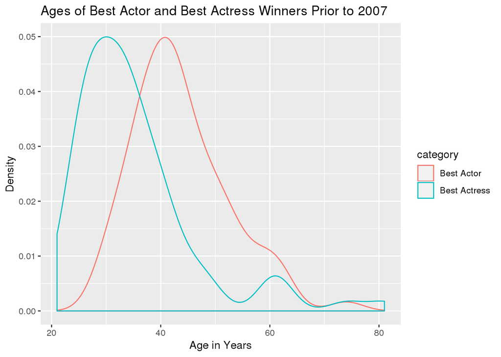

```r
ggplot(filter(OSCAR2007, category %in% c("Best Actor", "Best Actress")), aes(x = age, color = category)) +
  geom_density(alpha = 0.05) +
  ggtitle("Ages of Best Actor and Best Actress Winners Prior to 2007") +
  xlab("Age in Years") +
  ylab("Density")
```

8. In what way do these analyses support an assertion of age bias againt women in Hollywood? What are the limitations of this dataset if we want to generalize to all actors and actresses?

ANSWER: Looking at the five-number summary, the two groups have similar variability (based on their IQRs), but the median age of Best Actor winners is nine years older than the median of Best Actress winners. Additionally there is a ten-year difference between their respecive Q1 and Q3 values. We see a similar gap in the peaks of the density plots. A Best Actor winner isn’t unusually old until he reaches what many would consider a typical retirement are of 65, but women’s upper fence is ten years less than that, and to be a lower outlier an actress would have to be a young child. A decade is a relatively long time in the span of an adult career. Although there are some outliers in both groups, the middle values of the five-number summary are resistant to outliers, so they suggest a systematic difference in this elite group. However, these data are limited with respect to all of Hollywood because it does not include TV actors or actors who do primarily commercials or voice work.

### PROBLEM 2

In class, we examined the height variable in the Anthropometric dataset and discussed that the overall distribution is non-normal and potentially multimodal. It may be that males and females have different height distributions that are being mixed together, so it does not make sense to treat them as one group in an analysis. (data: anthropometric.csv)

1. If we analyze self-identified males and females separately, is the distribution of each group approximately normal? Create a density plot, ECDF plot and QQ plot for each group. Also compute skewness and kurtosis. Use this information to support your answer.

Self-Identified Female Students

```r
ANTF <- ANT %>% filter(gender == "female")

mF <- mean(ANTF$height, na.rm = TRUE)
sF <- sd(ANTF$height, na.rm = TRUE)

ANTF %>% summarize(skew = skewness(height, na.rm = TRUE),
                   kurt = kurtosis(height, na.rm = TRUE))
```

```
##        skew     kurt
## 1 0.6001424 3.507427
```

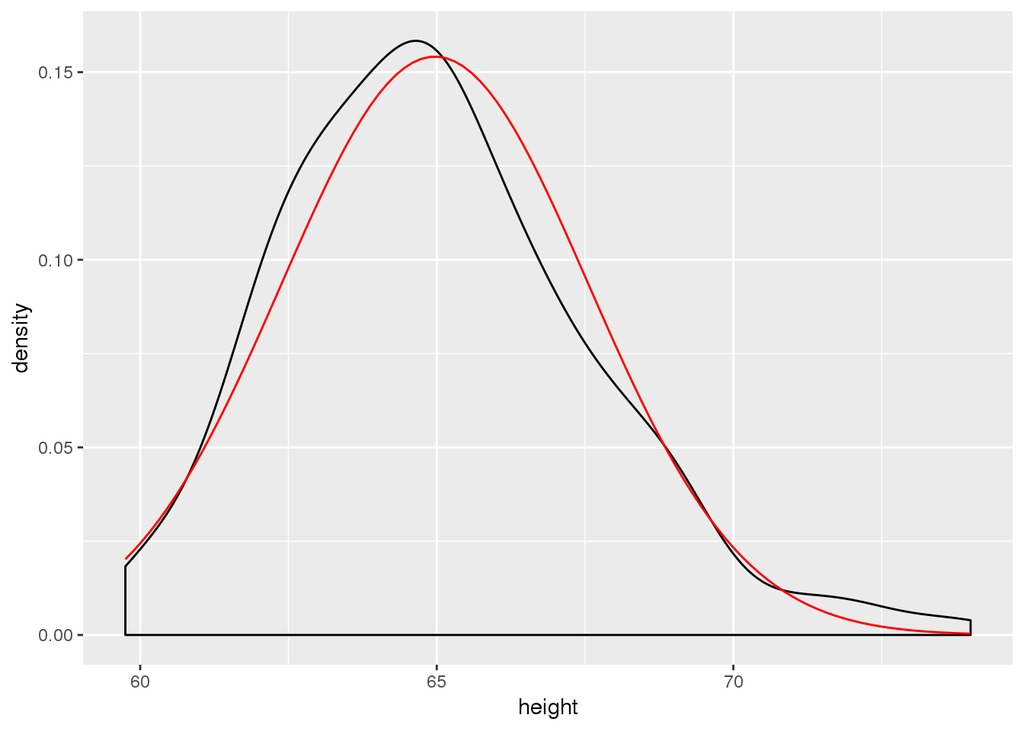

```r
ggplot(ANTF, aes(x = height)) +
  geom_density() +
  stat_function(fun = dnorm, args = list(mF, sF), color = "red")
```

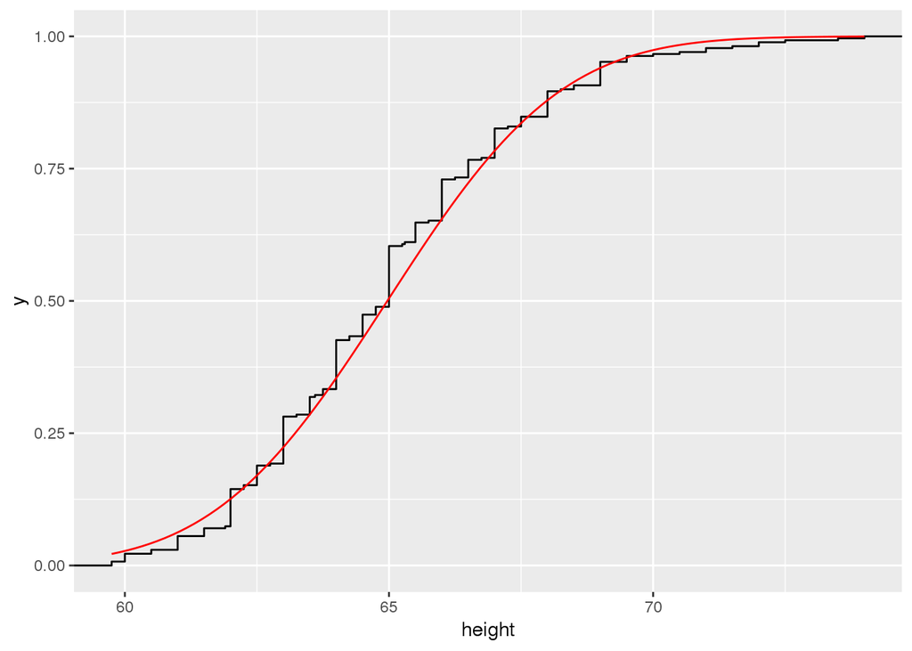

```r
ggplot(ANTF, aes(x = height)) +
  stat_ecdf() +
  stat_function(fun = pnorm, args = list(mF, sF), color = "red")
```

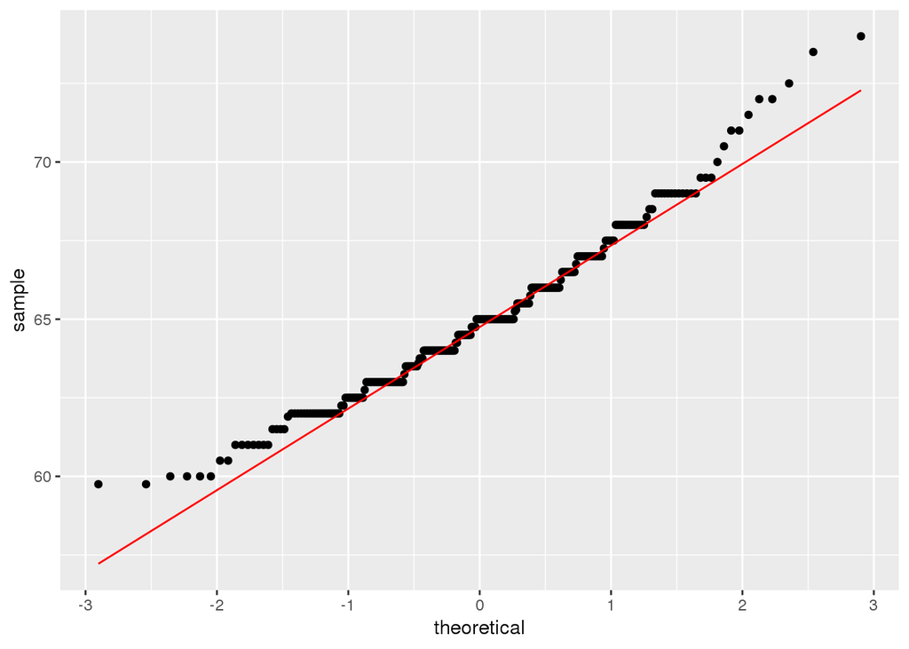

```r
ggplot(ANTF, aes(sample = height)) +
  geom_qq() +
  geom_qq_line(color = "red")
```

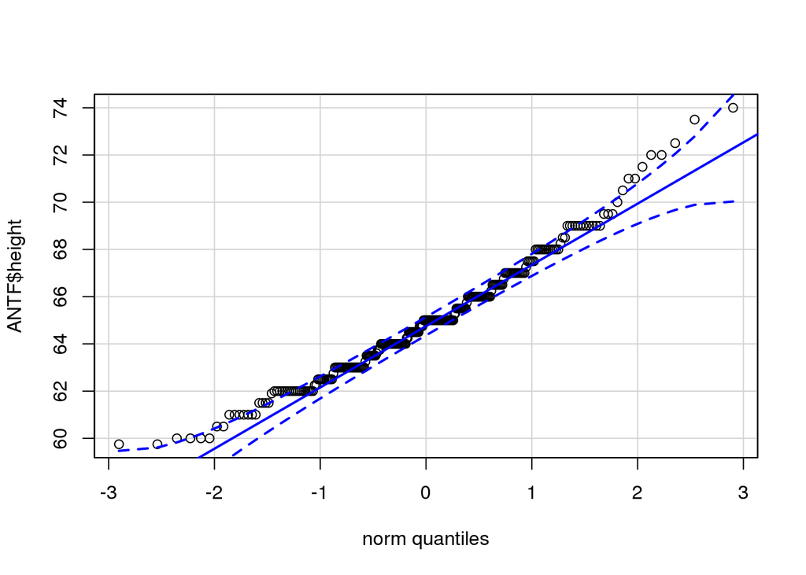

```r
qqPlot(ANTF$height, id = FALSE)
```

Self-Identified Male Students

```r
ANTM <- ANT %>% filter(gender == "male")

mM <- mean(ANTM$height, na.rm = TRUE)
sM <- sd(ANTM$height, na.rm = TRUE)

ANTM %>% summarize(skew = skewness(height, na.rm = TRUE),
                   kurt = kurtosis(height, na.rm = TRUE))
```

```
##           skew     kurt
## 1 -0.003997369 2.565045
```

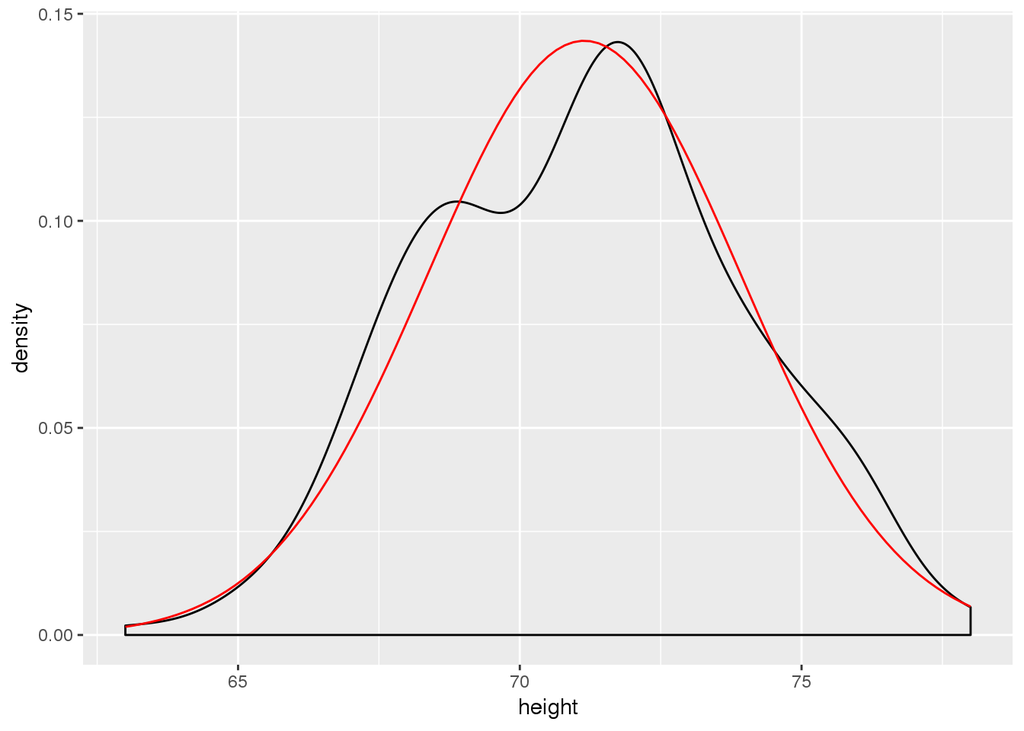

```r
ggplot(ANTM, aes(x = height)) +
  geom_density() +
  stat_function(fun = dnorm, args = list(mM, sM), color = "red")
```

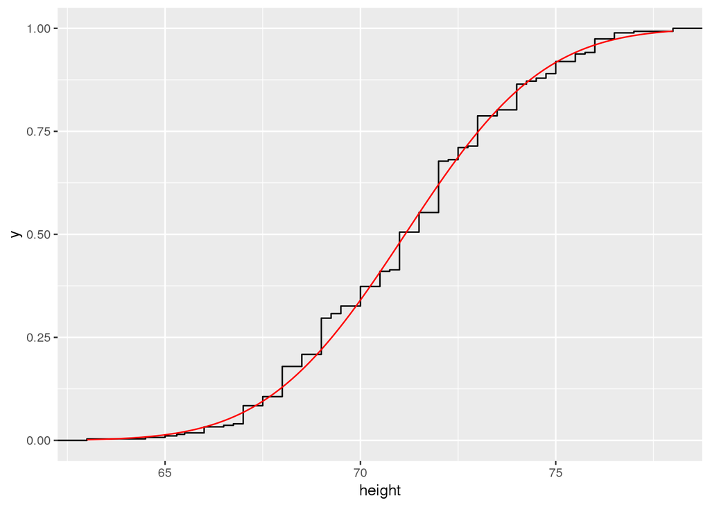

```r
ggplot(ANTM, aes(x = height)) +
  stat_ecdf() +
  stat_function(fun = pnorm, args = list(mM, sM), color = "red")
```

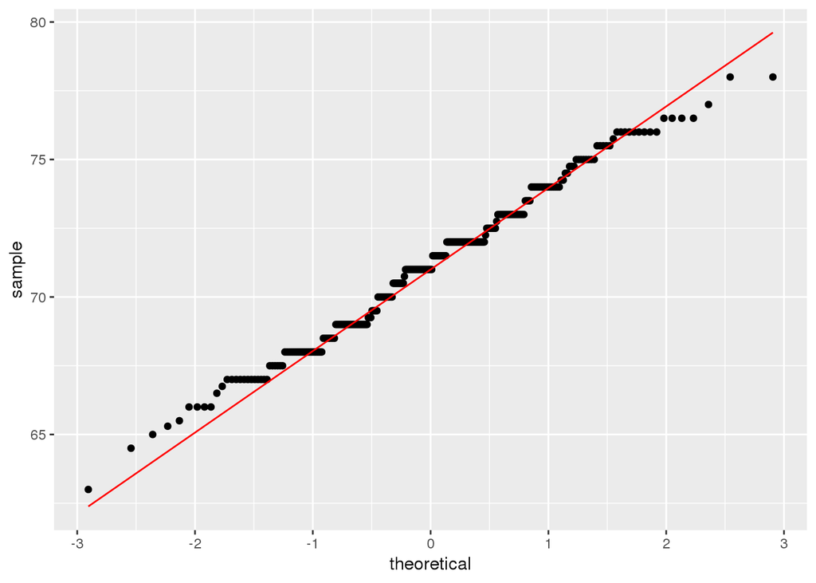

```r
ggplot(ANTM, aes(sample = height)) +
  geom_qq() +
  geom_qq_line(color = "red")
```

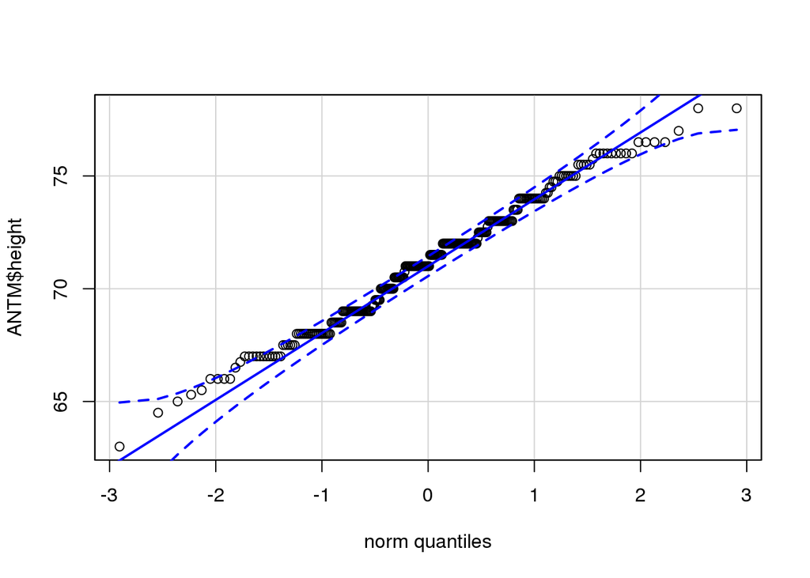

```r
qqPlot(ANTM$height, id = FALSE)
```

Alternatively, both groups on the same plots

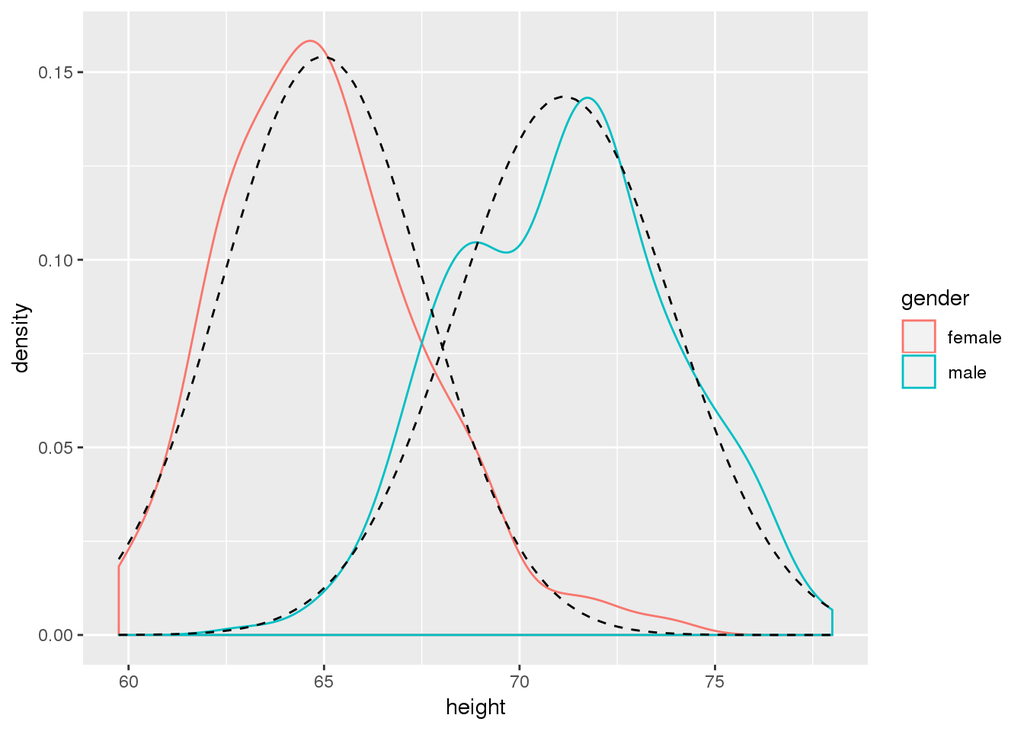

```r
ANT2 <- ANT %>% filter(gender %in% c("male", "female"))

mM   <- as.numeric(filter(ANT2, gender == "male") %>% summarize(mean(height, na.rm = TRUE)))
sM   <- as.numeric(filter(ANT2, gender == "male") %>% summarize(sd(height, na.rm = TRUE)))
mF   <- as.numeric(filter(ANT2, gender == "female") %>% summarize(mean(height, na.rm = TRUE)))
sF   <- as.numeric(filter(ANT2, gender == "female") %>% summarize(sd(height, na.rm = TRUE)))

ggplot(ANT2, aes(x = height, color = gender)) +
  geom_density() +
  stat_function(fun = dnorm,
                args = list(mF, sF),
                linetype = "dashed",
                color = "black") +
  stat_function(fun = dnorm,
                args = list(mM, sM),
                linetype = "dashed",
                color = "black")
```

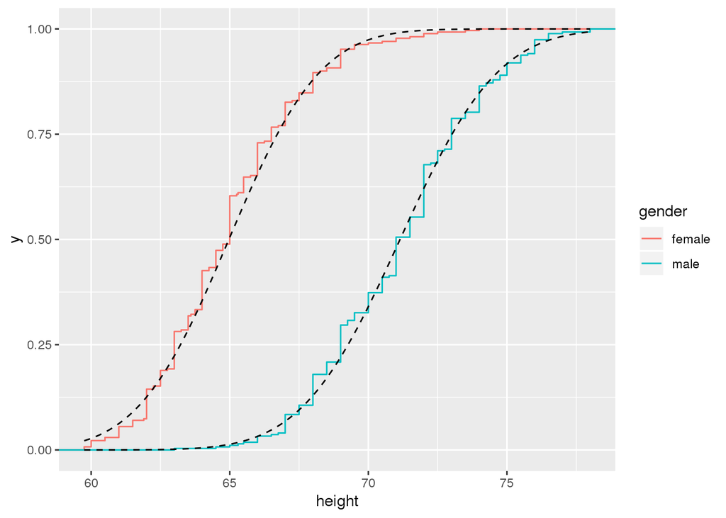

```r
ggplot(ANT2, aes(x = height, color = gender)) +
  stat_ecdf() +
  stat_function(fun = pnorm,
                args = list(mF, sF),
                linetype = "dashed",
                color = "black") +
  stat_function(fun = pnorm,
                args = list(mM, sM),
                linetype = "dashed",
                color = "black")
```

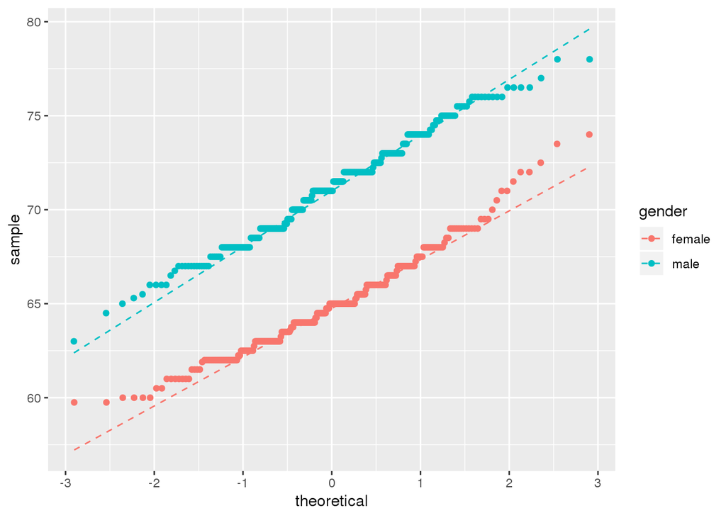

```r
ggplot(ANT2, aes(sample = height, color = gender)) +
  geom_qq() +
  geom_qq_line(aes(color = gender), linetype = "dashed")
```

ANSWER: The data for self-identified female students is somewhat right skewed. The skewness value exceeds 0.5 and the kurtosis is greater than three, which are characteristics of skewed data. These values support what we see in the plots. The density plot had a long right tail but its left tail looks truncated or “chopped off,” the left side of the ECDF plot also looks truncated, and the data on the QQplot curves upward away from the reference line at both ends. In many ways the data for self-identified male students seems relatively normal (skewness near zero, data following the line on the QQplot and ECDF plot), but there us also evidence of bimodality in the density plot and the kurtosis is somewhat less than three, probably due to the lower mode making the peak somewhat flatter.

2. Do the two groups have similar centers? What about spreads? Compute the mean, standard deviation, median, and IQR for each group and present these statistics all together in a single tibble. Use this information to support your answer.

```r
ANT %>%
  filter(gender %in% c("male", "female")) %>%
  group_by(gender) %>%
  summarize(mean  = mean(height, na.rm = TRUE),
            stdev = sd(height, na.rm = TRUE),
            med   = median(height, na.rm = TRUE),
            IQR   = IQR(height, na.rm = TRUE))
```

```
## # A tibble: 2 x 5
##   gender  mean stdev   med   IQR
##   <fct>  <dbl> <dbl> <dbl> <dbl>
## 1 female  65.0  2.59    65   3.5
## 2 male    71.1  2.78    71   4
```

ANSWER: Based on the mean and median, the two groups have centers that are about six inches apart, which is relatively large in the context of human heights. Looking at the standard deviation and IQR, the two groups’ spreads are very similar, differing by half an inch or less.

### PROBLEM 3

A digital communication channel transmits binary signals (digits 0 or 1). Suppose a particular system is susceptible to electronic interference, so there is a 5% chance that any bit sent by the system will be incorrectly received (i.e., we send a 0 and it is mistakenly interpreted as 1). Assume that the interference is non-patterned, so all bit transmission errors are random and independent of one another. One simple method for error reduction is repetition code. For critical messages, the digits are transmitted as repeated blocks of five identical digits (a single 0 in the message would be sent as the block 00000 and a single 1 would be sent as 11111). The receiver uses “majority logic decoding” on blocks. If the majority of the five-block’s digits are interpreted by the receiver as 0, then the transmitted digit represented by the block is recorded as a single 0. If the majority are interpreted as 1, then the transmitted digit is recorded as a 1.

1. What is the probability that any single five-block (e.g., 00000) is interpreted correctly?

```r
blockprob <- pbinom(2, 5, 0.05)
print(blockprob)
```

```
## [1] 0.9988419
```

2. In ASCII code, each letter is represented by a sequence of eight 0’s and 1’s. For example, 01001010 is the capital letter J. If we transmit a letter using the 5-block system described above, what is the probability that the letter will be interpreted correctly at the receiving end?

```r
bitprob <- dbinom(8, 8, blockprob)
print(bitprob)
```

```
## [1] 0.9907725
```

3. Using this system, what is the probability that your last name would be transmitted with at most one incorrect letter?

```r
# for my last name Thomley (7 letters)
# calculating chance of 0 or 1 errors

pbinom(1, 7, 1 - bitprob)
```

```
## [1] 0.9982661
```

```r
# for different possible last names...
# calculating chance of 0 or 1 errors

length <- 2:15
chances <- data.frame(letters = length, prob = pbinom(1, length, 1 - bitprob))
print.data.frame(chances)
```

```
##    letters      prob
## 1        2 0.9999149
## 2        3 0.9997461
## 3        4 0.9994954
## 4        5 0.9991641
## 5        6 0.9987539
## 6        7 0.9982661
## 7        8 0.9977024
## 8        9 0.9970640
## 9       10 0.9963524
## 10      11 0.9955691
## 11      12 0.9947154
## 12      13 0.9937927
## 13      14 0.9928023
## 14      15 0.9917456
```

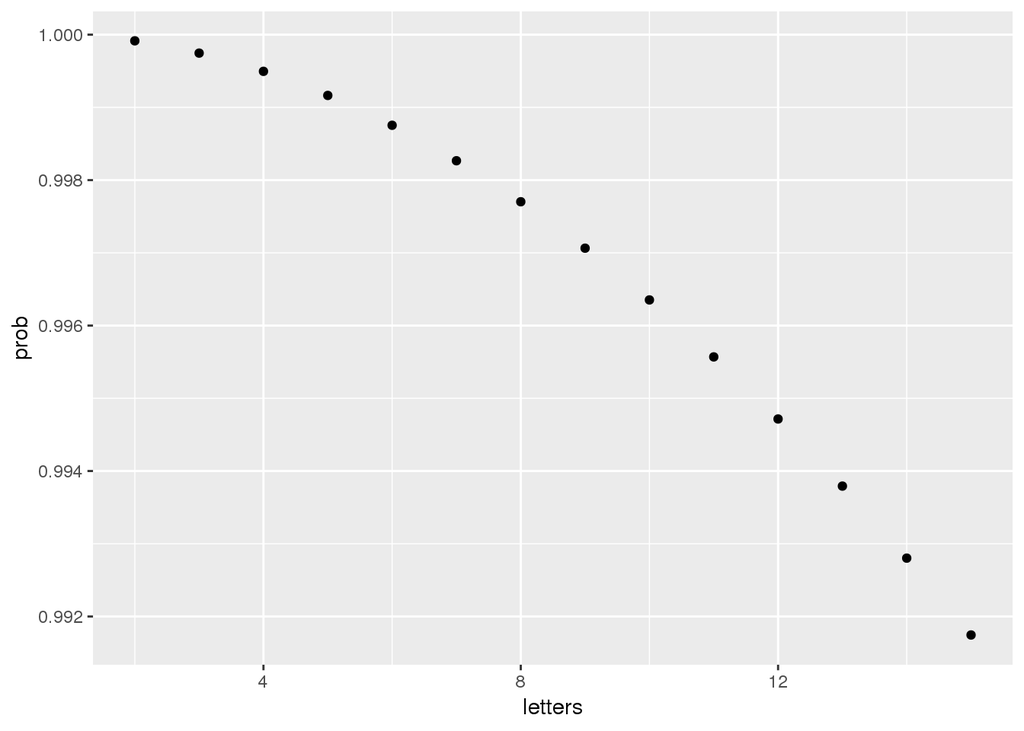

```r
# visualizing the various probabilities
# chances go down as name length goes up

ggplot(chances, aes(x = letters, y = prob)) + geom_point()
```

4. Suppose we could improve the performance of the system by shielding the equipment better to reduce the initial 5% single-digit chance of error. Create a plot that shows x = chance of error from 0% to 5% (in 0.1% increments) versus y = chance that a five-block is interpreted correctly at that error rate. How much do we have to reduce the single-digit error rate in order to achieve greater than a 99.9% chance of correct block interpretation?

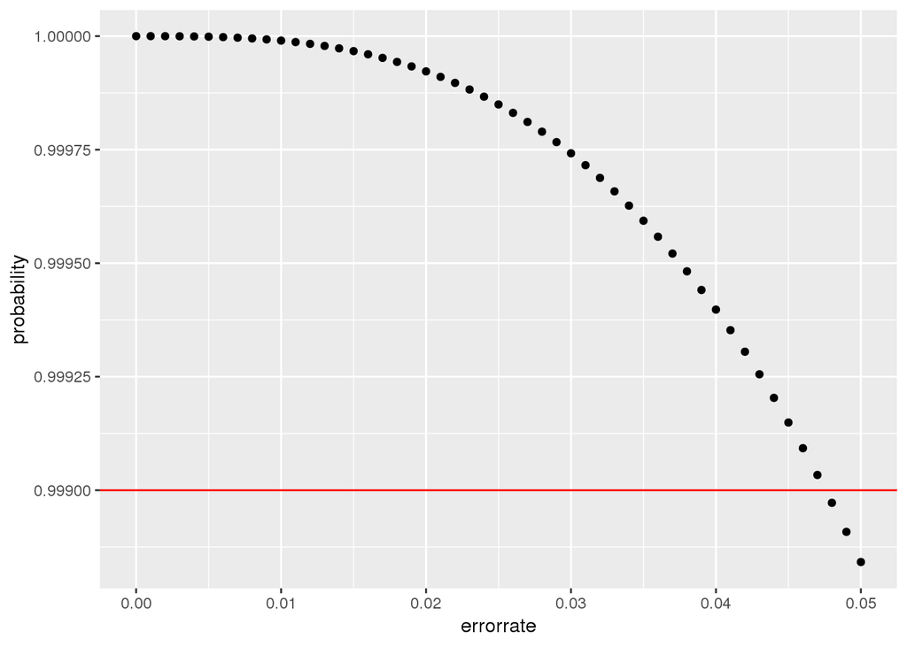

```r
# same calculation as (a) but with several probabilities

rates <- seq(0, .05, .001)
probs <- pbinom(2, 5, rates)
plotdata <- data.frame(errorrate = rates, probability = probs)
ggplot(plotdata, aes(x = errorrate, y = probability)) +
  geom_point() +
  geom_hline(yintercept = 0.999, color = "red")
```

```r
(plotdata %>% filter(probability > 0.999) %>% arrange(probability))[1,]
```

```
##   errorrate probability
## 1     0.047   0.9990336
```

### PROBLEM 4

A company uses an automated process to fill two-liter soda bottles. The amount of soda dispensed into a single bottle varies according to a normal distribution with a mean of 2.01 liters and a standard deviation of 10 milliliters (the equivalent of about two teaspoons, not enough for most consumers to notice).

1. What percentage of bottles actually have less than 2 liters of soda in them?

```r
pnorm(2, 2.01, .01)
```

```
## [1] 0.1586553
```

2. A bottle filled with more than 2.05 liters has a risk of exploding during transport. The machine fills 200 bottles per minute for 8 hours per day. How many bottles in one day’s run could potentially go kaboom?

```r
pnorm(2.05, 2.01, .01, lower.tail = FALSE) * 200 * 60 * 8
```

```
## [1] 3.040439
```

3. The quality control engineers want to adjust the mean fill setting on the machine so that no more than 5% of the bottles contain less than 2 liters of soda. If the process standard deviation stays the same, what does the new mean have to be (use three decimal places) to achieve the goal of no more than 5% underfilling?

```r
# you can solve this by iterative guess and check, the
# answer would have to be larger than the mean of 2.01
# consider using vectors to check many answers at once

# using a vector of possible means to get probabilities
# but then you have to visually inspect a lengthy list

means <- seq(from = 2.01, to = 2.05, by = .001)
data.frame(mu = means,
           prob = round(pnorm(2, means, .01), 4))
```

```
##       mu   prob
## 1  2.010 0.1587
## 2  2.011 0.1357
## 3  2.012 0.1151
## 4  2.013 0.0968
## 5  2.014 0.0808
## 6  2.015 0.0668
## 7  2.016 0.0548
## 8  2.017 0.0446
## 9  2.018 0.0359
## 10 2.019 0.0287
## 11 2.020 0.0228
## 12 2.021 0.0179
## 13 2.022 0.0139
## 14 2.023 0.0107
```

[output cut: 27 more lines]

```r
# we can pull the right answer from the list using code
# manipulate the data frame so the answer becomes row 1

means <- seq(from = 2.01, to = 2.05, by = .001)
results <- data.frame(mu = means,
                      prob = round(pnorm(2, means, .01), 4)) %>%
             filter(prob < 0.05) %>%
             arrange(desc(prob))
results[1,]
```

```
##      mu   prob
## 1 2.017 0.0446
```

```r
# this can be done using a repeating a loop as well
# the loop stops when the correct value is achieved
# we did not learn this in class, it is an extension

mu <-2.01
repeat
{
  chance1 <- pnorm(2, mu , .01);
  if(chance1 < 0.05) break;
  mu <- mu + 0.001;
}
print(mu)
```

```
## [1] 2.017
```

4. Instead of raising the mean fill level, the company decides to invest in a different machine that will reduce the variability in the fill process, which should address both the overfill and the underfill problems. If the mean stays at 2.01, what does the standard deviation need to be (use three decimal places) to achieve the goal of no more than 5% underfilling

```r
# using a vector of sigmas

sigmas <- seq(from = .01, to = .001, by = -.001)
results <- data.frame(sigma = sigmas, prob = round(pnorm(2, 2.01, sigmas), 4)) %>%
             filter(prob < 0.05) %>%
             arrange(desc(prob))
results[1,]
```

```
##   sigma   prob
## 1 0.006 0.0478
```

```r
# using a repeating loop

sigma <-0.01
repeat
{
  chance2 <- pnorm(2, 2.01, sigma);
  if(chance2 < 0.05) break;
  sigma <- sigma - 0.001;
}
print(sigma)
```

```
## [1] 0.006
```

5. Use `rnorm` to simulate a full day’s run of bottles for the scenario in (c). Do another simulation for the scenario in (d). Find the number of overfull bottles in each scenario.

```r
sum(rnorm(200*60*8, mu, .01) > 2.05)
```

```
## [1] 37
```

```r
sum(rnorm(200*60*8, 2.01, sigma) > 2.05)
```

```
## [1] 0
```

DONE!!!